# Your Digest for Saturday, Oct 28, 2023 11:59 PM

# 🔖Endocrine regulation of fluid balance it's disorders

#2022BSQ-OCT/Q10  
3. Release of vasopressin from the **hypothalamus**  
4. Direct increase of activity of **Na/H antiporter** -> **increased Na reabsorption** (in the **proximal** tubule)

> Angiotensin I then is converted to angiotensin II in the **lungs** **and kidneys** by angiotensin-converting enzymes (ACE). Angiotensin II is an octapeptide that is activated by type-1, **G protein-coupled angiotensin II receptors**. These receptors have different functions depending on the types of cells that contain the receptor. *However, it has five primary functions that include: increasing aldosterone, increasing sodium-hydrogen exchange within the proximal renal tubule, increasing thirst drive within the hypothalamus, increasing antidiuretic hormone, and acting on G protein-coupled receptors that activate IP3/Ca2+ second messenger systems within arterioles to cause vasoconstriction*. Aldosterone then undergoes its actions within the kidney.

#### 📑Aldosterone

1. Angiotensin II (mainly)
- Increased sodium reabsorption by increasing ENaC expression  
  **Therefore, effect is hypervolemia, increased Sodium reabsorption, hypokalemia and metabolic alkalosis.**

> Spironolactone - used to treat Conn's syndrome - is contraindicated in pregnancy because as *antiandrogen* it can cause feminization of a male foetus.  
> + Alpha intercalated cells - *Increases expression of H+ ATPase* -> increased secretion of H+ into the lumen
> - 📑Impaired glucose tolerance (hypokalemia inhibits insulin secretion)

##### Mechanism of hypotension in adrenal crisis

- Salt wasting and dehydration
- Glucocorticoids deficiency causes hypotension by *impaired vascular responsiveness to angiotensin II and norepinephrine*, ↑ prostacyclin production and ↓ renin substrate (?angiotensinogen) production.
- Also, glucocorticoids are required for free water excretion which also contributes to the hyponatremia.
- predominant symptom is **shock** + constitutional symptoms - fatigue, lethargy, N/V, abdominal pain.
- Primary chronic adrenal insufficiency - weakness, malaise, anorexia, weight loss
- Secondary or tertiary chronic adrenal insufficiency :

## 🔖Diabetic nephropathy

#2022BSQ-OCT/Q15  
* At least **two of three urine collections** obtained over a three- to six-month should have *elevate albumin* for dianosis of albuminuria.  
*Microscopic haematuria can occur in DM*. but **dysmorphic red cells** is highly specific for **non diabetic kidney disease**

> The gold standard for diagnosis of **diabetic nephropathy is biopsy**. But for practial reasons, when the clinical picture is suggestive, most patients with DM + kidney disease are managed as having diabetic nephropathy.  
> 1. DM -> *somehow ↑ RAAS activity* -> **increased GFR** -> In early stages of DM: Glomerular *hyperfiltration*.  
> 3. *Hyperfiltration is associated with increased risk of progression of kidney function decline*.
2. Oxidative stress and inflammation
   1. DM -> Advanced Glycation End products (*AGE*) -> **inflammation**
   2. DM -> Hyperglycaemia -> ↑ activity of **hexosamine pathway** +↑ RAAS acvitity -> *↑ TGF-Beta* production -> **fibrosis** and atrophy  
      *Mesangial proliferation* -> further proliferation + matrix deposition -> **PAS positive** **kimmelstiel-Wilson** bodies.
3. **Nodular** glomerular sclerosis <- a pattern of sclerosis with nodules of matrix at the *periphery of the glomerulus*. AKA **Kimmelstiel Wilson** nodules. <- Pathognomonic of DM (almost)
4. 📑❗**Glomerular basement membrane thickening is the first to be seen**.
- Efferent and afferent arteriolar **hyalinosis** - **Deposition of plasma proteins** (complement, immunoglobulins and fibrinogen) replace the smooth muscle cells of arteriole.
  1. Target HBA1C of **< 7** (subject to individual considerations)
5. ❗*Spironolactone can be used because it **reduces albuminuria*** but risk of hyperkalemia.
   1. 📑Finerenone causes less hyperkalemia.  
      **📑SGLT2 inhibitors are not appropriate for use in patients with type 1 diabetes and kidney disease.**

### 🔖Overview of physiology

T3 binds to **nuclear receptor** --> Exerts effects

## 🔖Functions of thyroid hormone

[output not shown]

```
- It increases rate of depolarization, repolarization and *decreases duration of action potentials*. Probably increases dromotropy as well. Effects are probably mediated by increased expression of Na/K ATPase and increased ion permeability. [Source](https://academic.oup.com/edrv/article/26/5/704/2355198) <- super detailed, don't read. ;)
```

- In hyperthyroidism, there is *widened pulse pressure*. (contributed to be *decreased* peripheral resistance). [Source](https://www.ncbi.nlm.nih.gov/pmc/articles/PMC8558494/)
- To emphasize the effect on lipid metabolism, *hypo*thyroidism causes *hypercholesterolemia*.
- *Thyroid hormone (and hyperthyroidism) increases hepatic LDL receptors which* promotes biliary excretion of cholesterol (leading to lower cholesterol levels)

## 🔖Investigation of thyroid function

> **Thyroid peroxidase** – TPO catalyzes the iodination of tyrosine residues of Tg to form monoiodotyrosine and diiodotyrosine. Nearly all patients with ❗**Hashimoto's thyroiditis** have high serum concentrations of ❗TPO antibodies.

## 🔖Hyperthyroidism

- Autoimmunity -> TSH-Receptor antibodies (thyrotropin receptor or TRAb) stimulate thyroid gland to make thyroid hormones. -> *diffuse, **non tender**, goiter*. (MCQ Point: TSH receptor *inhibiting antibodies are also formed*)
- Histology: Diffuse, **hyperplasia and hypertrophy**; follicular cells become tall and columnar with crowding and formation of papillae with no neovascularization. 📑T cell infiltrates are present within thyroid.
- *Orbitopathy* and *pretibial myxoedema* are not related to thyroxine levels. Pretibial myxoedema is caused by deposition of **glycosaminoglycans** and **T cell infiltration**.

> **Ophthalmopathy** is characterized by inflammation of the extraocular muscles and orbital fat and connective tissue, which results in proptosis (**exophthalmos**), **impairment of eye muscle function**, and **periorbital edema**.  
> Volume of retro-orbital tissue is increased by **1)** *T cell infiltration*, **2)** *Inflammatory oedema*, **3)** *Increased extracellular matrix deposition*, **4)** *increased adipocytes*.  
> As above, lid *retraction is more suggestive of Grave's ophthalmopathy*.

### 🔖Management of hyperthyroidism

#2022BSQ-NOV/Q32  
#2022BSQ-OCT/Q1

# 🔖Cell injury

## 🔖Overview of cell injury

#2022BSQ-OCT/Q12

# 🔖Overview of types of necrosis

```
- Characteristic of *infarcts of solid organs*; the insult disrupts digestive proteins as well so that tissue architecture is preserved for *days to weeks* until phagocytic leukocytes migrate in and digest the debris.
- Occurs at the *site of an infection*. But hypoxic insult in the CNS also causes liquefactive necrosis.
```

- Caseous necrosis:
  - Cheese like; **characteristic of TB infection**. The necrotic mass is friable, like cheese. Cellular architecture is not preserved, unlike coagulative necrosis. Often surrounded by an inflammatory border.
  - This lady knows what is looks like.--> ;) [Source:Video](https://youtu.be/eYpW9m-AB1A?t=6)

# 🔖Tay Sach's disease

#2022BSQ-NOV/Q56

#2022BSQ-OCT/Q04  
📑*DMARDs takes months to act*.  
❗  
🔖

# 🔖Neurocysticercosis

#2022BSQ-OCT/Q5

> [!TIP] Mnemonic :"Solium polium" - solium = pork tapeworm.  
> Only pork tape worm causes cysticercosis  
> 📑**ONLY TAENIA SOLIUM** causes **CYSTICERCOSIS**.  
> Pigs are the usual intermediate host, 🔖Humans are the definitive host.  
> cysticercosis results *from humans acting as 🔖accidental intermediate hosts* for the parasite  
> - Live cysts: Antihelminthing treatment must be *combined with steroid which penetrates the BBB (Dexamethasone)* to lessen the inflammatory response elicited following death of the parasite.  
> - 🔖Praziquental and albendazole.

# 🔖Granuloma formation and patterns

> 1. *Epithelialization* : where the cell membranes begin to *interdigitate*.
> 2. *Giant cell* formation.
> 3. This is when *multiple macrophages fuse* to form a giant cell with multiple nuclei.  
>    Specially, *Th cells* have a significant role to play here.  
>    The pattern of inflammation can be classified in many ways. (necrotizing or not / Suppurative or not etc.)  
>    - eg **Tuberculous** and other **infectious granulomas** (fungal ones where the pathogen is intracellular). [Source](https://www.annualreviews.org/doi/10.1146/annurev-immunol-032712-100022)  
>    - Other examples of **necrotizing granulomas**: **rheumatoid nodules** and **granulomatosis with polyangiitis** and occasionally those in **sarcoidosis**.  
>    | Cat Scratch disease | Rounded or **stellate**, central debris present. |  
>    | Syphillitic gumma | **Central necrosis** but with preserved cell outlines, *plasma cell* infiltrate |

## 🔖Granulomatous diseases

# 🔖Pyoderma gangrenosum

- **Rheumatoid arthritis**
- **Ulcerative colitis** and Chron's (to a lesser extent)  
  #2022BSQ-OCT/Q2
1. Seeding of body cavities : Typical of **ovarian CA**
2. ❗Lymphatic spread : more typical or **carcinoma**
   1. Arteries are *less easily penetrated than veins*. ❗Mets occur along venous drainage.
   2. All portal drainage goes to the liver; all caval blood flows to the lung -> these capillary beds are the main sites of metastasis in ❗haematogenous metastasis.
3. ❗Thyroid and prostate CA metastasize via the paravertebral plexus -> vertebral metastases.
   1. bone metastases are more frequent in *follicular* and *medullary* thyroid cancers
4. ❗Renal and hepatic CA like to grown inside veins:
   1. ❗Renal - *renal veins* and IVC
   2. ❗Liver *hepatic veins* and IVC
5. Path of venous drainage alone doesn't account for the distribution of particular metastatic tumours; Some tumours have a propensity to metastasize to particular organs. This may be due to *chemoattraction* or expression of tissue specific adhesion molelcules by tumour cells.
   1. ❗**prostatic** carcinoma preferentially spreads to **bone**,
   2. ❗**bronchogenic** carcinomas tend to involve the **adrenals**
   3. and the brain, and **neuroblastomas** spread to the *liver* and **bones**.

# 🔖Atherosclerosis

#2022BSQ-OCT/Q08

## 🔖Selected gastrointestinal regulatory peptides

#2022BSQ-OCT/Q24  
*Vasoactive intestinal peptide (VIP)* -> Secreted by enteric **NERVES** -> Neurotransmitter, Stimulates insulin release, splanchnic vasodildation and intestinal secretion of water and electrolytes; also *relaxes smooth muscles*, including the lower esophageal sphincter and colon  
Mnemonic: VIP readies the stomach and gut receival of food.

*Glucose dependent insulinotropic polypeptide* - **GIP** - - From duodenum, gastric antrum and ileum - stimulated by *intraduodenal* glucose -> **incretin** effect. (produced by K cells)  
*GLP-1* - The main actions of GLP-1 are to *stimulate insulin secretion* (i.e., to act as an **incretin** hormone) and to *inhibit glucagon secretion*, to limit postprandial glucose rise. Secreted by **L cells in the ileum and colon**.

> [!TIP] Mnemonic: All of these hormones generally cause changes which promote digestion and absorption except for *somatostatin*  
> **Somatostatin**: somatostatin decreases endocrine and exocrine secretion and blood flow, *reduces gastrointestinal motility* and *gallbladder contraction, and inhibits secretion of most gastrointestinal hormones*.

Secretin: physiologic role increases pancreatic bicarbonate secretion and inhibits gastrin production. But in gastric CA, administration of secretin causes *increased* gastrin production. (paradoxically)

# 🔖Bilirubin physiology and elevations

> The transport proteins requried for reabsorption are affected in **Rotor syndrome** -> leads to conjugated and unconjugated hyperbilirubinaemia.(mostly conjugated)  
> ?? are the only causes of unconjugated hyperbiliribunaemia CN , Gilbert and haemolytic anaemias?

> [!INFO] DDx of **conjugated hyperbilirubinaemia**  
> And this table which Medscape made incredibly hard to copy.

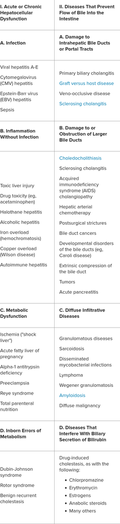

> 1. It's possible in cirrhosis but usually, "*conjugation is better preserved than other aspects of bilirubin metabolism like canalicular secretion*".  
> 2. **Gentamicin** can inhibit UGT1A1 -> *unconjugated hyperbilirubinaemia*

# 🔖Complement system overview

> - **Promote inflammation** through C3a, C4a and C5a
> - **Recruit cells** (through chemoatractants)
> - Solubilitze antigen-antibody complexes and remove them from circulation

# 🔖Causes of increased CPK

#2022BSQ-OCT/Q31  
CPK is eliminated by the *❗Reticuloendothelial system❗*. **Serum level isn't elevated in kidney disease**.  
+ Drugs - *colchicine* (gout), antimalarials, statins, alcohol  
+ Metabolic myopathies - *carnitine palmitoyltransferase deficiency*, Muscle phosphorylase deficiency (*McArdle's disease*)  
+ McArdles disease - #autosomal-Recessive , exercise intolerance in *childhood* followed by *cramps and myoglobinuria*  
+ *❗motor neuron disease❗*

# 🔖Urine cultures

We want to get urine samples which contain bacteria which have managed to enter the bladder. (bacteria colonize the distal urethra and genital mucosa)  
*Prostatic massage* should be done prior to urine sample correction in suspected if *chronic bacterial prostatis* is suspected. ❗Massage should be **avoided in acute bacterial prostatits -> risk of bactiraemia!**  
Sample is cooled until it is sent to the lab to prevent bacterial multiplication affecting the colony count.

## Urine microscopy

- *bacteuria without pyuria* -> usually means colonization rather than infection. (unless of course, patient is symptomatic)
- *False -ve for bacteria*
- *False +ve for leukocytes*
  - Chronic intersitial nephritis - *omeprazole is a cause*.

[figure not shown]

## Cardiac action potentials

Source: CVS physiology website.

### 🔖ECG changes in hyperkalemia :

| Level | Changes | Basis |
| --- | --- | --- |
| 5.5 - 6.5 | 📑 Tall t waves | ❗ **Repolarization abnormalities** |
| 6.5 - 7 | 📑 P wave widening and flattening, broadening of PR interval | ❗**Progressive atrial paralysis** |
| 7.0 - 9.0 | 📑 Sinus brady, AV block, AF, conduction blocks | ❗Conduction abnormalities |
| > 9.0 | Sine wave | ❗Peri arrest |

- Diminished T wave, increased U wave, *ST depression* [Source](https://emj.bmj.com/content/19/1/74)  
  The U-wave is a deflection following the T wave. Potassium levels that are critically low (<1.7 mmol/L) can lead to **torsades de pointes** or “twisting of the points”, a polymorphic ventricular tachycardia.
> - *it's size increases with decreasing hear rate*
> - *Best seen in V2 and V3*.

## Hypermagnesaemia

#TODO  
#2021BSQ-JUL/Q31

> 2. Carcinoembryonic Antigen (**CEA**) - Colorectal cancer, pancreatic cancer, lung cancer
> 3. **CA 19-9** - Pancreatic cancer, colorectal cancer
> 4. **CA 15-3 - Breast cancer**
> 5. **CA 27-29 - Breast cancer**  
>    resection is curative in UC but disease recurs after resection in Crohn's;  
>    **Mnemonic: "Colectomy is curative"**

| Endoscopy | **Cobblestones** + linear ulcers | Diffuse *continuous* involvement, **pseudopolyps** |

> [!INFO] NOTE! Crypt abssesses are present in both but more common in ulcerative colitis.  
> Peak incidence for both is between **15-30 years**. But disease can occur at any age.
> - ❗primary sclerosing cholangitis (seen *mostly* with UC)
> - more likely to develop pyoderma gangrenosum
- *Weight loss appears to be more common in Crohn's disease*.
- You'd expect that to be due to malabosorption but megaloblastic anaemia is 'unusual' in crohn's disease (and UC doesn't involve the small intestine anyway) -> ?probably due to systemic effect of chronic inflammation.
3. Kidney stones- seen in crohn's disease (?could be due to defective enterohepatic circulation of bile salts)  
   Ileal resection can cause *bile acid malabsorption* -> diarrhoea.
- ❗**steroids** - oral or IV
- ❗Second line agent - **anti TNF-alpha antibodies** -> **infliximab**, **adalimumab**; best used **in combination with azathioprine.**
- Local **5 amino salicilates** are the **mainstay** of treatment. (**Mesalazine** , Olsalazine, Balsazide, Sulfasalazine)
- They act **topically**.
- Delivered via **enema** (for left sided colitis) or suppository (proctitis) or oral for extensive disease.
- Second line options for resistant disease: *anti TNF-alpha inhibitors (infliximab, adalimumab)* or anti integrin (vedolizumab), or tofacitinib(Oral inhibitor of JAK pathway).

# 🔖Primary sclerosing cholangitis

- Progressive and chronic liver disease caused by autoimmune mediated fibrosis of **intra** and **extrahepatic** bile ducts.
- Strongly associated with IBD (mainly ❗**ulcerative colitis**)
- Associated with ❗**pANCA** positivity.
- Treatment is *not curative*; it's aimed at minimizing symptoms and managing complications.
- ❗**Liver transplantation**❗ is the only treatment than can *alter progression*. Drugs won't work.
  - PSC *without IBD is more likely to occur in women*.
  - Mmemonic: (Remember that smoking protects against ulcerative colitis! *so if you smoke, you have less risk of UC and associated PSC*)
- Ix: AST, ALT, **GGT** all elevated. **Fluctuating** **conjugated** hyperbilirubinaemia.
- **pANCA** positivity is a feature.
- ❗**hypergammaglobulinaemia** is present.

# 🔖Primary Biliary Cirrhosis / Primary Biliary Cholangitis

> Suspect in a middle aged **woman** with **pruritus** who has elevated ALP and possible other autoimmune conditions.  
> [!TIP] Mnemonic: Don't confuse with PSC - PBC has 'cirrhosis' in the name -> live tissue is inolved -> interlobular bile ducts are involved.  
> **Middle aged, itchy woman** - Karens  
> ALP is the only abnormal investigation  
> Most often diagnosed through **routine** screening.  
> ❗**Usually asymptomatic.** -
- There is destruction of small **❗interlobular** *bile ducts*.
- ❗**Antimitochondrial** antibodies are found in all patients. M2 is specific for PBC.
  - > The presence of *serum antimitochondrial antibodies* (AMA) is a highly specific indication of [primary biliary cirrhosis](http://emedicine.medscape.com/article/171117-overview) (PBC).
  - Also anti *GP210* - corelates with development of liver failure.
  - > In Primary Biliary Cirrhosis, the level of ALP is generally greater than that of GGT. In this case, transaminases are *invariably normal* or only minimally elevated.[Source](https://www.ncbi.nlm.nih.gov/pmc/articles/PMC3609680/)
- Raised *cholesterol and Xanthelasma*
- Also associated with **RTA**. - but ?rare

# 🔖Immunoglobulin / antibody classes

#2022BSQ Q49

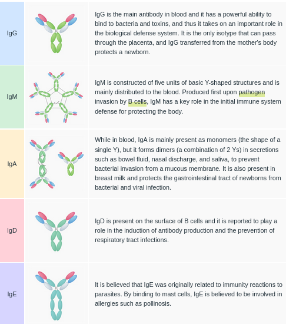

[Source](https://www.kyowakirin.com/antibody/basics/isotypes.html)

- *Only IgG can pass through the placenta*!
- IgA is present in breast milk as well!

# 🔖Insulin

#2022BSQ-OCT/Q40  
❗(U-100) denotes the usual concentration (100 U/ml).

- Duration: **Short acting**.
- Controls post prandial glucose rise.
- Same AA sequence as human insulin.
- Bound to **Zinc**.
- Hexamers must be converted to dimers and monomer before absorption -> leads to a delay in peak concentrations-> should be given **30 minutes before meals**.
- Duration of action tends to exceed duration of post prandial glucose rise -> risk of hypoglycaemia.  
  Suspension of human insulin, **protamine** and zinc. -> delays release of insulin into blood, also *longer time to peak*.  
  **NPH insulin is a cloudy solution**.  
  *Always draw up the regular(clear) insulin first* to avoid contaminating the regular insulin with isophane insulin, thereby altering its pharmacokinetics.  
  Substitution of amino acids produces rapid acting and long acting analogs.  
  Lispro, aspart, **glulisine** (and faster aspart, lipro-aabc)

> modifications were made in the insulin molecule to *prevent it from forming hexamers or polymers* that slow absorption and delay action  
> Insulin **aspart**- substitution of aspartic acid for **proline** at position B28.  
> Insulin **lispro** is identical to human regular insulin except for a *lysine* and *proline* at positions *B28 and B29*.  
> Insulin **glulisine** has a *lysine and glutamic acid* at positions B3 and B29 respectively.  
> Rapid acting insulins are more convenient.  
> **Insulin detemir** – Detemir is an acylated insulin; the *fatty acid side chain allows reversible albumin binding* as well as concentration-dependent self-association (ie, formation of dihexamers) that results in prolongation of action.  
> ❗Can't mix with rapid acting insulins.  
> After subcutaneous administration, *glargine precipitates in the tissue,* forming hexamers, which delays absorption and prolongs duration of action.  
> Glargine, which is in an **acidic** solution, **cannot be mixed with rapid-acting insulins**, as the kinetics of both the glargine and rapid-acting insulin will be altered  
> Duration of action : 24 hours but some may need twice daily dosing as half life is 12 hours. Unlike glargine, determir has a *small peak* in it's concentration profile.  
> [!TIP] Degludec - the only long acting insulin that can be mixed with rapid acting insuline Mnemonic: Glue - glue it up.  
> - *reduced by smoking*

# 🔖Types of hypersensitivity

| Type 1 | Type 2 | Type 3 | Type 4 |
| --- | --- | --- | --- |
| Immediate hypersensitivity - eg analphylaxis | 2-24 hours | days to weeks | 2 days |
| IgE (from plasma cells) mediated | **IgG and IgM** - bind to own cell surface molecules -> *complement activated* | **IgG and IgM** antigen antibody *complexes* | **Cell** mediated - *non antibody dependant* - **T cells, monocytes and macrophages** |
| degranulation of mast cells and basophils | complement mediated red cell agglutination and other cell lysis |  | Cytokines which cause cell death and inflammation are released |

## 🔖Autoimmune diseases examples

# 🔖 Infectious diarrhoea

- can be studied under *inflammatory diarrhoeal* causes and *watery diarrhoeal causes.*

> "**Noninflammatory** diarrhea is caused by the action of **enterotoxins** on the *secretory mechanisms* of the mucosa of the small intestine, without invasion" - Medscape.
> 1. Norovirus (mnemonic : N for 'naught' for day zero)
> 2. E coli - *enterotoxigenic*

#### Giardiasis

- Giardia lamblia - 'old mans face appearance', protozoan.
- Causes water diarrhoea after a few weeks -> cyst is the infective state; cysts produced trophozoites which attach in the small intestine and colon.
- Cyst is the infective stage.
- Trophozoite attaches to *proximal* small intestine, sometimes causing villous atrophy.
- Abdominal pain, water diarrhoea, weight loss.
- Diagnosis : stool microscopy, string test.
- High risk: Immunocompromised, infants
- Treatment: tinidazol, metronidazole is second line due to concern of side effects. Achieves parasite clearance within 1 week.
2. Shigella dysenteriae (bloody diarrhoea) - *SD1 serotype*. (inflammatory diarrhoea - blood + mucous)  
   #2021BSQ-NOV/Q37
- *Vomiting predominates* in the clinical picture.
  - and **Bacillus cereus**
- Pin worm.
- Humans are considered the only host for *E. vermicularis*
- Infection is commonest in children and institutionalised people.
- Treatment is easy; reinfection is also easy.
- Commonest symptom: *itching in the perianal area*, possible with excoriation and secondary bacterial infection.
- Perianal itching / scratching contributes to faeco-oral transmission of the parasite.
- Infection of the female genital tract can occur. Can cause abdominal pain mimicking appendicitis.
- Treatment: Albendazole, mebendazole
- *Strongyloides stercoralis* : thread worm
- First discovered in french troops returning from vietnam in the 19th century who developed *chronic diarrhoea*.
- Infective stage : **Filariform larva:** -> *penetrates intact skin*.
- Shows ❗autoinfection.

> parasite has a *free living cycle* and parasitic cycle.  
> Eggs -> rhabditiform larvae -> **filariform larvae**. (Infective stage) (autoinfection or otherwise).  
> **It has been thought that the L3 larvae migrate via the bloodstream and lymphatics to the lungs, where they are eventually coughed up and swallowed**. However, L3 larvae appear capable of migrating to the intestine via alternate routes (e.g. through abdominal viscera or connective tissue)

```
3. **Gastrin** from **G cells** in the ***antrum of the pylorus***  stimulates *histamine* release from ECL cells (fundic glands)-> *histamine* stimulates acid secretion from parietal cells
1. Somatostatin - **potent anti acid hormone**. Secreted by ***D cells*** located throughout gastric mucosa and from *oxyntic glands.* It inhibits histamine release -> *reduces parietal cell acid production*.
```

#2022BSQ-OCT/Q07  
Strongly associated with *C. difficile infection*. Therefore, use should be minimized.

# The final push 💪🏼

## Main goals

Finish reading the notes.  
Finish reviewing all your images.  
Do some Anki  
Review the daily digests.  
2018 GM question paper

## Markdown notes

> [!INFO] Median size: **8572 KB**

> [!INFO] Finish 12 notes per day from large and small sections

## Time allocation

60% for reading notes  
20% for the images  
10% for the GM paper  
5% for anki  
5% for the digests

12 hours / day =>  
7.2 hours for the notes  
2.4 hours images  
1.2 hours GM paper  
35 minutes ANKI  
35 minutes Digest

- Terlipressin - Vasopressin analog - reduced blood flow into portal vessels and reduces portal pressure.

### Typical histiologic features of viral hepatitis / AIH

| Hep B | Hep C | Autoimmune |
| --- | --- | --- |
| Ground glass | Fatty change + portal lymphoid aggregates | Plasma cell infiltrate |